# Milestone 5

Tim Ravis

3/29/2020

This is my Milestone 5 PDF.[^1]

## A 300 – 500 word overview of your replication paper. What analysis did they run? What did they conclude?

My project’s replication paper is titled “Titling community land to prevent deforestation: An evaluation of a best-case program in Morona-Santiago, Ecuador.” This is an evaluation of the impact of a donor-funded land titling and land management program for indigenous communities in Ecuador. They believe that this is virtually a best-case policy intervention. The data for the model was generated from spatial data on intervention areas and title boundaries provided by USAID and NGOs and publicly available spatial raster data such as population density (Landscan) and forest cover (Global Forest Change (GFC) by Hansen et al). The change in GFC in an area is used as the metric for deforestation. Areas receiving the program treatment were matched with areas that did not receive the treatment using a genetic matching algorithm. The treatment effect over the five years after is then estimated with a difference-in-difference OLS model. They find that treatment does not have a significant effect on deforestation rates.

# References

Agrawal, A. 2001. “Common Property Institutions and Sustainable Governance of Resources.” *World Development*, no. 29: 1649–1672.

E.Y. Arima, S.G. Perz, R.T. Walker. 2005. “Loggers and Forest Fragmentation: Behavioral Models of Road Building in the Amazon Basin.” *Annals of the Association of American Geographers*, no. 95: 525–41.

K.S. Andam, A. Pfaff, P.J. Ferraro. 2008. “Measuring the Effectiveness of Protected Area Networks in Reducing Deforestation.” *Proceedings of the National Academy of Sciences*, no. 105: 16089–94.

L.J. Alston, R. Schneider, G.D. Libecap. 1996. “The Determinants and Impact of Property Rights: Land Titles on the Brazilian Frontier.” *Journal of Law, Economics, & Organization*, no. 12: 25–61.

M.T. Buntaine, M. Millones, S.E. Hamilton. 2015. “Titling Community Land to Prevent Deforestation: An Evaluation of a Best-Case Program in Morona-Santiago, Ecuador.” *Global Environmental Change*, no. 33: 32–43.

# Appendix

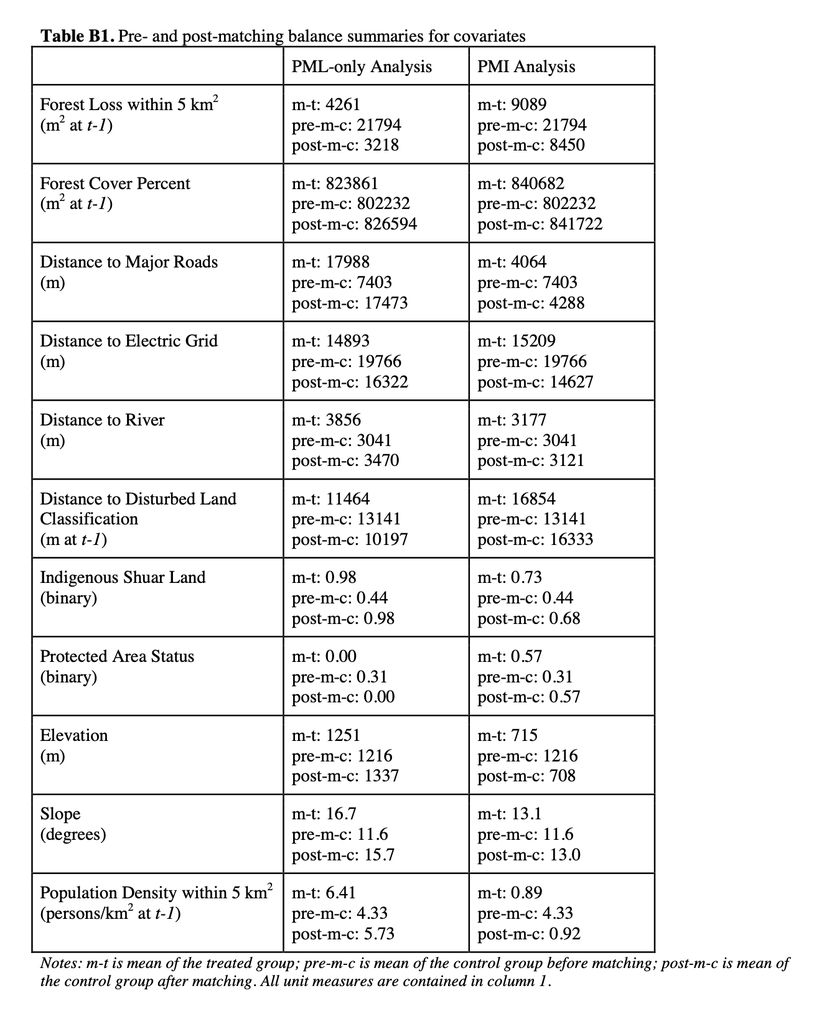

[^1]: * All analysis and data for this paper [is available here](https://github.com/soetimno/ravis_1006_final_project.git)